# Coin Toss and R Markdown Introduction

yKim

2024-09-19

## R Markdown (src: RStudio)

## Math 2265 Section 4.1

### Load Packages

```r
library(openintro)
```

```r
library(ggplot2)
library(tinytex)  # to knit to PDF
set.seed(2265)
```

### Short Recap

In the following, we plot the box plot of the variable `interest_rate` in the dataset `loan50`. See how R Markdown runs R code.

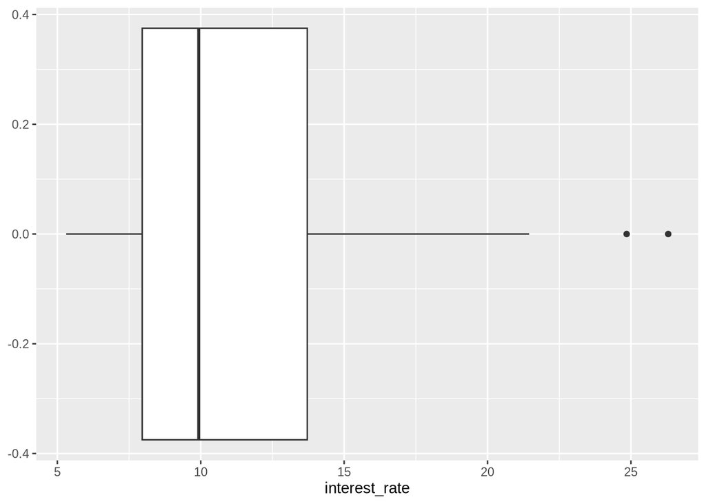

```r
ggplot(data=loan50, mapping=aes(x=interest_rate)) +
  geom_boxplot()
```

### Heads and Tails

We make a simulation of a fair coin toss. Recall there is an equal change of getting a head or tail.

```r
coin <- c("H", "T") # define a vector consisting of "H" and "T"
sample(coin, 1)
```

```
## [1] "T"
```

Execute this cell by clicking on the green |> button.

Change the code to run the simulation 10 times.

```r
coin <- c("H", "T") # define a vector consisting of "H" and "T"
sample(coin, 10)
```

```
## Error in sample.int(length(x), size, replace, prob): cannot take a sample larger than the population when 'replace = FALSE'
```

This will result in an error since we want to grab 10 when there are only two. We can set the `replace` parameter `TRUE`.

```r
coin <- c("H", "T") # define a vector consisting of "H" and "T"
sample(coin, 10, replace = TRUE)
```

```
##  [1] "H" "H" "H" "H" "T" "H" "H" "H" "T" "H"
```

```r
# table(sample(coin, 10, replace = TRUE))
```

Run this a few times.

## Questions

**Question 1.** Did you get the even number of heads and tails?

**Ans:** No in general

**Question 2.** Complete the following code to simulate tossing a coin 500 times.

```r
coin <- c("H", "T") # define a vector consisting of "H" and "T"
result <- sample(coin, 500, replace = TRUE)
table(result) # `table` tallies the result
```

```
## result
##   H   T
## 242 258
```

Run this code a few times.

> **The Law of Large Numbers** As more observations are collected, the proportion of occurrences with a particular outcome converges to the probability of that outcome.

**Question 3.**

The following code runs 1000 simulations of tossing coins 500 times and saves the number of heads in each simulation to the variable `num_heads.`

```r
coin <- c("H", "T") # define a vector consisting of "H" and "T"
num_heads <- replicate(1000, as.numeric(table(sample(coin, 500, replace = TRUE))[1]))
data_coin <- data.frame(
  num_heads
) # it will be used in the next question
num_heads[1:5] # prints the first 5 results
```

```
## [1] 252 241 253 255 258
```

Make a histogram of the simulations with the bin number of your choice.

```r
print(str(data_coin))
```

```
## 'data.frame':    1000 obs. of  1 variable:
##  $ num_heads: num  252 241 253 255 258 240 241 228 246 255 ...
## NULL
```

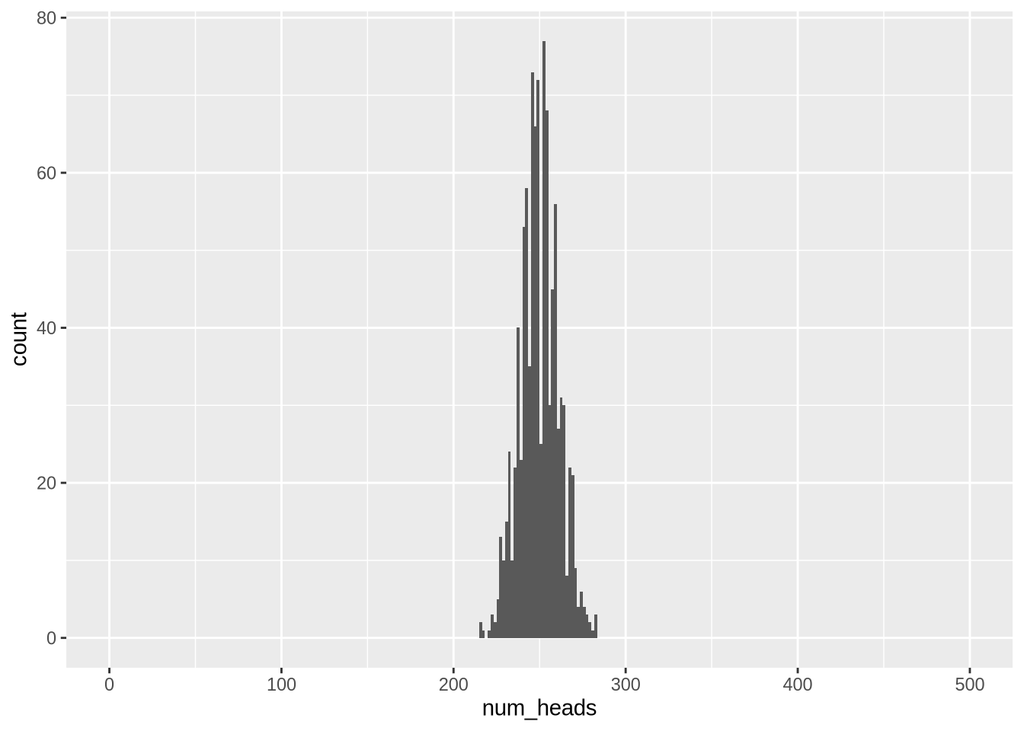

```r
ggplot(data=data_coin, aes(x=num_heads)) +
  xlim(0, 500) + # to make it to display x from 0 to 500
  geom_histogram(bins=300)
```

### Example of an unfair coin.

In this example, we have an unfair coin where the change of getting tail is 75%. Compare this histogram and the one you made in the previous question.

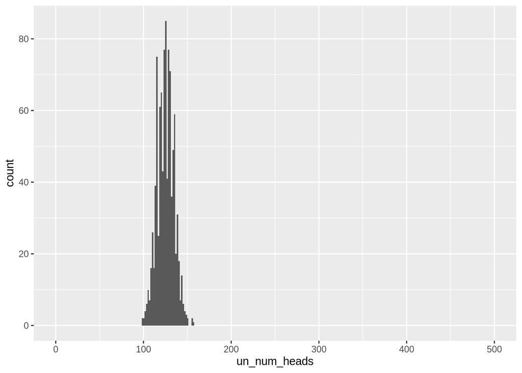

```r
coin <- c("H", "T") # define a vector consisting of "H" and "T"
un_num_heads <- replicate(1000, as.numeric(table(sample(coin, 500, replace = TRUE, prob=c(0.25,0.75)))[1]))
data_un_coin <- data.frame(
  un_num_heads
) # it will be used in the next question
ggplot(data=data_un_coin, aes(x=un_num_heads)) +
  xlim(0, 500) +
  geom_histogram(bins=300)
```

**Question 4.**

Which simulation has a bigger mean of the number of heads? (fair coin vs. unfair coin above) To answer this question, it may help uncommenting the line `xlim(0, 500) +`.

**Ans:** The fair coin simulation

## Upload your work to Canvas